# Risk Factor Analysis

## Outcome Variable

**Outcome Variable:** stunted

## Predictor Variables

**Intervention Variable:** anywast06

**Adjustment Set:**

- arm
- sex
- brthmon
- W_mage
- meducyrs
- hhwealth_quart
- W_nrooms
- month
- W_parity
- delta_W_mage
- delta_meducyrs
- delta_hhwealth_quart
- delta_W_nrooms
- delta_month
- delta_W_parity

## Stratifying Variables

The analysis was stratified on these variable(s):

- agecat
- studyid
- country

## Data Summary

| agecat | studyid | country | anywast06 | stunted | n_cell | n |
| --- | --- | --- | --- | --- | --- | --- |
| Birth | CMC-V-BCS-2002 | INDIA | 0 | 0 | 30 | 92 |
| Birth | CMC-V-BCS-2002 | INDIA | 0 | 1 | 7 | 92 |
| Birth | CMC-V-BCS-2002 | INDIA | 1 | 0 | 45 | 92 |
| Birth | CMC-V-BCS-2002 | INDIA | 1 | 1 | 10 | 92 |
| Birth | CMIN | BANGLADESH | 0 | 0 | 13 | 20 |
| Birth | CMIN | BANGLADESH | 0 | 1 | 2 | 20 |
| Birth | CMIN | BANGLADESH | 1 | 0 | 4 | 20 |
| Birth | CMIN | BANGLADESH | 1 | 1 | 1 | 20 |
| Birth | CONTENT | PERU | 0 | 0 | 2 | 2 |
| Birth | CONTENT | PERU | 0 | 1 | 0 | 2 |
| Birth | CONTENT | PERU | 1 | 0 | 0 | 2 |
| Birth | CONTENT | PERU | 1 | 1 | 0 | 2 |
| Birth | EE | PAKISTAN | 0 | 0 | 86 | 240 |
| Birth | EE | PAKISTAN | 0 | 1 | 70 | 240 |
| Birth | EE | PAKISTAN | 1 | 0 | 54 | 240 |
| Birth | EE | PAKISTAN | 1 | 1 | 30 | 240 |
| Birth | GMS-Nepal | NEPAL | 0 | 0 | 340 | 684 |
| Birth | GMS-Nepal | NEPAL | 0 | 1 | 82 | 684 |
| Birth | GMS-Nepal | NEPAL | 1 | 0 | 234 | 684 |
| Birth | GMS-Nepal | NEPAL | 1 | 1 | 28 | 684 |
| Birth | IRC | INDIA | 0 | 0 | 137 | 388 |
| Birth | IRC | INDIA | 0 | 1 | 27 | 388 |
| Birth | IRC | INDIA | 1 | 0 | 206 | 388 |
| Birth | IRC | INDIA | 1 | 1 | 18 | 388 |
| Birth | Keneba | GAMBIA | 0 | 0 | 934 | 1542 |
| Birth | Keneba | GAMBIA | 0 | 1 | 60 | 1542 |
| Birth | Keneba | GAMBIA | 1 | 0 | 526 | 1542 |
| Birth | Keneba | GAMBIA | 1 | 1 | 22 | 1542 |
| Birth | MAL-ED | BANGLADESH | 0 | 0 | 146 | 229 |
| Birth | MAL-ED | BANGLADESH | 0 | 1 | 31 | 229 |

[output cut: 170 more lines]

The following strata were considered:

- agecat: 24 months, studyid: CMC-V-BCS-2002, country: INDIA
- agecat: 24 months, studyid: CMIN, country: BANGLADESH
- agecat: 24 months, studyid: CONTENT, country: PERU
- agecat: 24 months, studyid: EE, country: PAKISTAN
- agecat: 24 months, studyid: GMS-Nepal, country: NEPAL
- agecat: 24 months, studyid: IRC, country: INDIA
- agecat: 24 months, studyid: Keneba, country: GAMBIA
- agecat: 24 months, studyid: MAL-ED, country: BANGLADESH
- agecat: 24 months, studyid: MAL-ED, country: BRAZIL
- agecat: 24 months, studyid: MAL-ED, country: INDIA
- agecat: 24 months, studyid: MAL-ED, country: NEPAL
- agecat: 24 months, studyid: MAL-ED, country: PERU
- agecat: 24 months, studyid: MAL-ED, country: SOUTH AFRICA
- agecat: 24 months, studyid: MAL-ED, country: TANZANIA, UNITED REPUBLIC OF
- agecat: 24 months, studyid: PROVIDE, country: BANGLADESH
- agecat: 24 months, studyid: TanzaniaChild2, country: TANZANIA, UNITED REPUBLIC OF
- agecat: 6 months, studyid: CMC-V-BCS-2002, country: INDIA
- agecat: 6 months, studyid: CMIN, country: BANGLADESH
- agecat: 6 months, studyid: CONTENT, country: PERU
- agecat: 6 months, studyid: EE, country: PAKISTAN
- agecat: 6 months, studyid: GMS-Nepal, country: NEPAL
- agecat: 6 months, studyid: Guatemala BSC, country: GUATEMALA
- agecat: 6 months, studyid: IRC, country: INDIA
- agecat: 6 months, studyid: Keneba, country: GAMBIA
- agecat: 6 months, studyid: MAL-ED, country: BANGLADESH
- agecat: 6 months, studyid: MAL-ED, country: BRAZIL
- agecat: 6 months, studyid: MAL-ED, country: INDIA
- agecat: 6 months, studyid: MAL-ED, country: NEPAL
- agecat: 6 months, studyid: MAL-ED, country: PERU
- agecat: 6 months, studyid: MAL-ED, country: SOUTH AFRICA
- agecat: 6 months, studyid: MAL-ED, country: TANZANIA, UNITED REPUBLIC OF
- agecat: 6 months, studyid: PROVIDE, country: BANGLADESH
- agecat: 6 months, studyid: ResPak, country: PAKISTAN
- agecat: 6 months, studyid: TanzaniaChild2, country: TANZANIA, UNITED REPUBLIC OF
- agecat: Birth, studyid: CMC-V-BCS-2002, country: INDIA
- agecat: Birth, studyid: CMIN, country: BANGLADESH
- agecat: Birth, studyid: CONTENT, country: PERU
- agecat: Birth, studyid: EE, country: PAKISTAN
- agecat: Birth, studyid: GMS-Nepal, country: NEPAL
- agecat: Birth, studyid: IRC, country: INDIA
- agecat: Birth, studyid: Keneba, country: GAMBIA
- agecat: Birth, studyid: MAL-ED, country: BANGLADESH
- agecat: Birth, studyid: MAL-ED, country: BRAZIL
- agecat: Birth, studyid: MAL-ED, country: INDIA
- agecat: Birth, studyid: MAL-ED, country: NEPAL
- agecat: Birth, studyid: MAL-ED, country: PERU
- agecat: Birth, studyid: MAL-ED, country: SOUTH AFRICA
- agecat: Birth, studyid: MAL-ED, country: TANZANIA, UNITED REPUBLIC OF
- agecat: Birth, studyid: PROVIDE, country: BANGLADESH
- agecat: Birth, studyid: ResPak, country: PAKISTAN

### Dropped Strata

Some strata were dropped due to rare outcomes:

- agecat: Birth, studyid: CMIN, country: BANGLADESH
- agecat: Birth, studyid: CONTENT, country: PERU
- agecat: Birth, studyid: MAL-ED, country: BRAZIL
- agecat: Birth, studyid: MAL-ED, country: INDIA
- agecat: Birth, studyid: MAL-ED, country: NEPAL
- agecat: Birth, studyid: MAL-ED, country: PERU
- agecat: Birth, studyid: MAL-ED, country: SOUTH AFRICA
- agecat: Birth, studyid: MAL-ED, country: TANZANIA, UNITED REPUBLIC OF
- agecat: Birth, studyid: ResPak, country: PAKISTAN
- agecat: 6 months, studyid: CONTENT, country: PERU
- agecat: 6 months, studyid: Guatemala BSC, country: GUATEMALA
- agecat: 6 months, studyid: MAL-ED, country: BRAZIL
- agecat: 6 months, studyid: MAL-ED, country: PERU
- agecat: 6 months, studyid: MAL-ED, country: TANZANIA, UNITED REPUBLIC OF
- agecat: 24 months, studyid: CONTENT, country: PERU
- agecat: 24 months, studyid: MAL-ED, country: BRAZIL
- agecat: 24 months, studyid: MAL-ED, country: PERU
- agecat: 24 months, studyid: MAL-ED, country: TANZANIA, UNITED REPUBLIC OF
- agecat: 24 months, studyid: TanzaniaChild2, country: TANZANIA, UNITED REPUBLIC OF

## Methods Detail

We’re interested in the causal parameters $E[Y_a]$ for all values of $a \in \mathcal{A}$. These parameters represent the mean outcome if, possibly contrary to fact, we intervened to set all units to have $A=a$. Under the randomization and positivity assumptions, these are identified by the statistical parameters $\psi_a=E_W[E_{Y|A,W}(Y|A=a,W)]$. In addition, we’re interested in the mean of $Y$, $E[Y]$ under no intervention (the observed mean). We will estimate these parameters by using SuperLearner to fit the relevant likelihood factors – $E_{Y|A,W}(Y|A=a,W)$ and $p(A=a|W)$, and then updating our likelihood fit using a joint TMLE.

For unadjusted analyses ($W=\{\}$), initial likelihoods were estimated using Lrnr_glm to estimate the simple $E(Y|A)$ and Lrnr_mean to estimate $p(A)$. For adjusted analyses, a small library containing Lrnr_glmnet, Lrnr_xgboost, and Lrnr_mean was used.

Having estimated these parameters, we will then use the delta method to estimate relative risks and attributable risks relative to a prespecified baseline level of $A$.

# Results Detail

## Results Plots

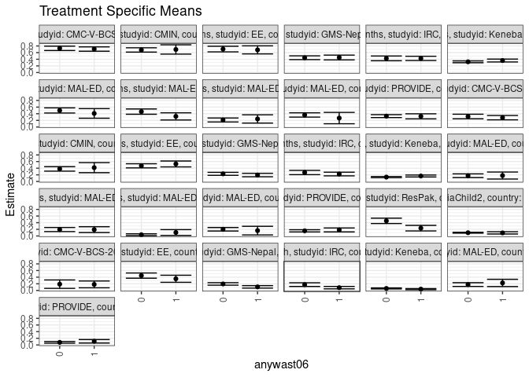

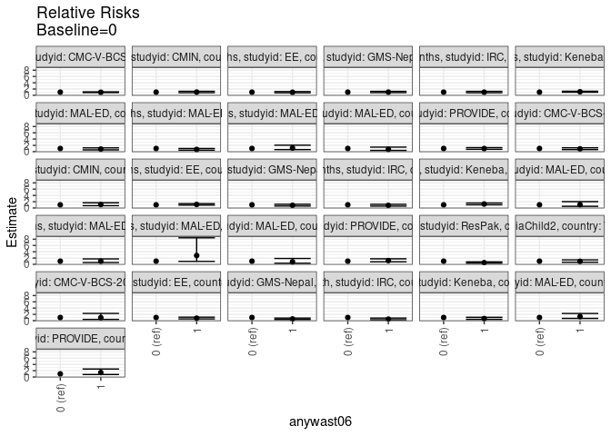

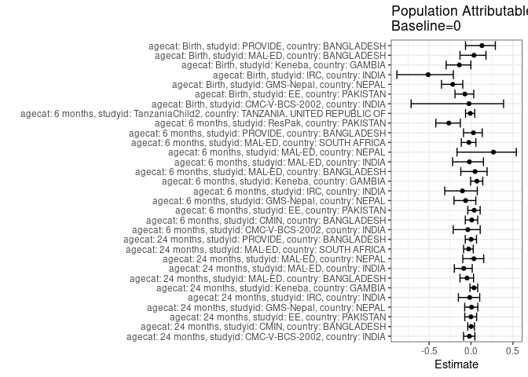

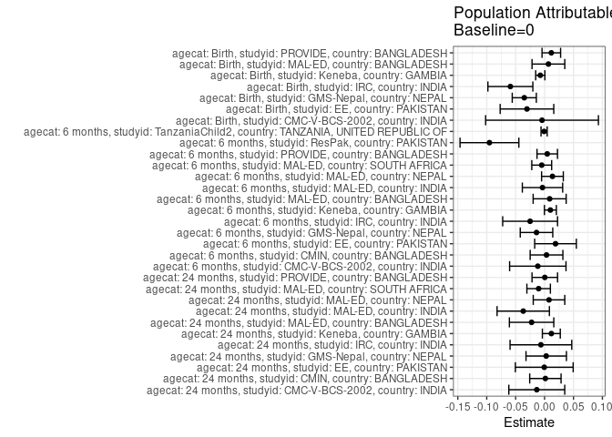

## Results Table

### Parameter: TSM

| agecat | studyid | country | intervention_level | baseline_level | estimate | ci_lower | ci_upper |
| --- | --- | --- | --- | --- | --- | --- | --- |
| Birth | CMC-V-BCS-2002 | INDIA | 0 | NA | 0.1891892 | 0.0622989 | 0.3160795 |
| Birth | CMC-V-BCS-2002 | INDIA | 1 | NA | 0.1818182 | 0.0793277 | 0.2843087 |
| Birth | EE | PAKISTAN | 0 | NA | 0.4471264 | 0.3688457 | 0.5254071 |
| Birth | EE | PAKISTAN | 1 | NA | 0.3513156 | 0.2450237 | 0.4576075 |
| Birth | GMS-Nepal | NEPAL | 0 | NA | 0.1958983 | 0.1579648 | 0.2338319 |
| Birth | GMS-Nepal | NEPAL | 1 | NA | 0.1073148 | 0.0696833 | 0.1449463 |
| Birth | IRC | INDIA | 0 | NA | 0.1751132 | 0.1197494 | 0.2304770 |
| Birth | IRC | INDIA | 1 | NA | 0.0841319 | 0.0483184 | 0.1199454 |
| Birth | Keneba | GAMBIA | 0 | NA | 0.0605724 | 0.0456886 | 0.0754562 |
| Birth | Keneba | GAMBIA | 1 | NA | 0.0395990 | 0.0230710 | 0.0561271 |
| Birth | MAL-ED | BANGLADESH | 0 | NA | 0.1767593 | 0.1204799 | 0.2330387 |
| Birth | MAL-ED | BANGLADESH | 1 | NA | 0.2260607 | 0.1164625 | 0.3356589 |
| Birth | PROVIDE | BANGLADESH | 0 | NA | 0.0773982 | 0.0512447 | 0.1035517 |
| Birth | PROVIDE | BANGLADESH | 1 | NA | 0.1091612 | 0.0572250 | 0.1610973 |
| 6 months | CMC-V-BCS-2002 | INDIA | 0 | NA | 0.3158089 | 0.2469830 | 0.3846347 |
| 6 months | CMC-V-BCS-2002 | INDIA | 1 | NA | 0.2817279 | 0.2165876 | 0.3468682 |
| 6 months | CMIN | BANGLADESH | 0 | NA | 0.3793409 | 0.3121297 | 0.4465521 |
| 6 months | CMIN | BANGLADESH | 1 | NA | 0.4169785 | 0.2649442 | 0.5690127 |
| 6 months | EE | PAKISTAN | 0 | NA | 0.4717023 | 0.4095213 | 0.5338834 |
| 6 months | EE | PAKISTAN | 1 | NA | 0.5280540 | 0.4390441 | 0.6170640 |
| 6 months | GMS-Nepal | NEPAL | 0 | NA | 0.2302650 | 0.1849698 | 0.2755602 |
| 6 months | GMS-Nepal | NEPAL | 1 | NA | 0.1953441 | 0.1433059 | 0.2473823 |
| 6 months | IRC | INDIA | 0 | NA | 0.2707128 | 0.2059159 | 0.3355098 |
| 6 months | IRC | INDIA | 1 | NA | 0.2246503 | 0.1697491 | 0.2795515 |
| 6 months | Keneba | GAMBIA | 0 | NA | 0.1319820 | 0.1144825 | 0.1494816 |
| 6 months | Keneba | GAMBIA | 1 | NA | 0.1656569 | 0.1360551 | 0.1952588 |
| 6 months | MAL-ED | BANGLADESH | 0 | NA | 0.1737965 | 0.1185272 | 0.2290657 |
| 6 months | MAL-ED | BANGLADESH | 1 | NA | 0.1791873 | 0.0738772 | 0.2844975 |
| 6 months | MAL-ED | INDIA | 0 | NA | 0.1942733 | 0.1327345 | 0.2558121 |
| 6 months | MAL-ED | INDIA | 1 | NA | 0.1905949 | 0.1030600 | 0.2781298 |
| 6 months | MAL-ED | NEPAL | 0 | NA | 0.0372340 | 0.0101120 | 0.0643560 |
| 6 months | MAL-ED | NEPAL | 1 | NA | 0.1041667 | 0.0175647 | 0.1907686 |
| 6 months | MAL-ED | SOUTH AFRICA | 0 | NA | 0.2017937 | 0.1490144 | 0.2545730 |
| 6 months | MAL-ED | SOUTH AFRICA | 1 | NA | 0.1612903 | 0.0315623 | 0.2910184 |
| 6 months | PROVIDE | BANGLADESH | 0 | NA | 0.1543307 | 0.1209763 | 0.1876852 |
| 6 months | PROVIDE | BANGLADESH | 1 | NA | 0.1819460 | 0.1220688 | 0.2418232 |
| 6 months | ResPak | PAKISTAN | 0 | NA | 0.4551504 | 0.3733846 | 0.5369162 |
| 6 months | ResPak | PAKISTAN | 1 | NA | 0.2351338 | 0.1508611 | 0.3194064 |
| 6 months | TanzaniaChild2 | TANZANIA, UNITED REPUBLIC OF | 0 | NA | 0.0978947 | 0.0838621 | 0.1119272 |
| 6 months | TanzaniaChild2 | TANZANIA, UNITED REPUBLIC OF | 1 | NA | 0.0932131 | 0.0591723 | 0.1272538 |
| 24 months | CMC-V-BCS-2002 | INDIA | 0 | NA | 0.7293168 | 0.6631242 | 0.7955094 |
| 24 months | CMC-V-BCS-2002 | INDIA | 1 | NA | 0.7077981 | 0.6426123 | 0.7729838 |
| 24 months | CMIN | BANGLADESH | 0 | NA | 0.6804169 | 0.6153718 | 0.7454620 |
| 24 months | CMIN | BANGLADESH | 1 | NA | 0.6948419 | 0.5543199 | 0.8353639 |
| 24 months | EE | PAKISTAN | 0 | NA | 0.7071128 | 0.6221554 | 0.7920702 |
| 24 months | EE | PAKISTAN | 1 | NA | 0.6822447 | 0.5608109 | 0.8036784 |
| 24 months | GMS-Nepal | NEPAL | 0 | NA | 0.4459382 | 0.3895731 | 0.5023033 |
| 24 months | GMS-Nepal | NEPAL | 1 | NA | 0.4532436 | 0.3818710 | 0.5246163 |
| 24 months | IRC | INDIA | 0 | NA | 0.4268839 | 0.3553451 | 0.4984227 |
| 24 months | IRC | INDIA | 1 | NA | 0.4260401 | 0.3622657 | 0.4898145 |
| 24 months | Keneba | GAMBIA | 0 | NA | 0.3229390 | 0.2951696 | 0.3507085 |
| 24 months | Keneba | GAMBIA | 1 | NA | 0.3617157 | 0.3185237 | 0.4049076 |
| 24 months | MAL-ED | BANGLADESH | 0 | NA | 0.4988567 | 0.4208469 | 0.5768665 |
| 24 months | MAL-ED | BANGLADESH | 1 | NA | 0.4090911 | 0.2646442 | 0.5535380 |
| 24 months | MAL-ED | INDIA | 0 | NA | 0.4642018 | 0.3845965 | 0.5438070 |
| 24 months | MAL-ED | INDIA | 1 | NA | 0.3199131 | 0.2117134 | 0.4281128 |
| 24 months | MAL-ED | NEPAL | 0 | NA | 0.2116424 | 0.1519971 | 0.2712878 |
| 24 months | MAL-ED | NEPAL | 1 | NA | 0.2427626 | 0.1180520 | 0.3674733 |
| 24 months | MAL-ED | SOUTH AFRICA | 0 | NA | 0.3632075 | 0.2983335 | 0.4280816 |
| 24 months | MAL-ED | SOUTH AFRICA | 1 | NA | 0.2692308 | 0.0983756 | 0.4400860 |
| 24 months | PROVIDE | BANGLADESH | 0 | NA | 0.3283708 | 0.2840584 | 0.3726832 |
| 24 months | PROVIDE | BANGLADESH | 1 | NA | 0.3215876 | 0.2456741 | 0.3975011 |

### Parameter: E(Y)

| agecat | studyid | country | intervention_level | baseline_level | estimate | ci_lower | ci_upper |
| --- | --- | --- | --- | --- | --- | --- | --- |
| Birth | CMC-V-BCS-2002 | INDIA | NA | NA | 0.1847826 | 0.1050392 | 0.2645260 |
| Birth | EE | PAKISTAN | NA | NA | 0.4166667 | 0.3541635 | 0.4791698 |
| Birth | GMS-Nepal | NEPAL | NA | NA | 0.1608187 | 0.1332679 | 0.1883695 |
| Birth | IRC | INDIA | NA | NA | 0.1159794 | 0.0840777 | 0.1478811 |
| Birth | Keneba | GAMBIA | NA | NA | 0.0531777 | 0.0419744 | 0.0643810 |
| Birth | MAL-ED | BANGLADESH | NA | NA | 0.1834061 | 0.1331729 | 0.2336393 |
| Birth | PROVIDE | BANGLADESH | NA | NA | 0.0890538 | 0.0649864 | 0.1131212 |
| 6 months | CMC-V-BCS-2002 | INDIA | NA | NA | 0.3041096 | 0.2568508 | 0.3513684 |
| 6 months | CMIN | BANGLADESH | NA | NA | 0.3827160 | 0.3214780 | 0.4439541 |
| 6 months | EE | PAKISTAN | NA | NA | 0.4906166 | 0.4398159 | 0.5414174 |
| 6 months | GMS-Nepal | NEPAL | NA | NA | 0.2163121 | 0.1823021 | 0.2503220 |
| 6 months | IRC | INDIA | NA | NA | 0.2457002 | 0.2038248 | 0.2875757 |
| 6 months | Keneba | GAMBIA | NA | NA | 0.1420233 | 0.1269309 | 0.1571158 |
| 6 months | MAL-ED | BANGLADESH | NA | NA | 0.1825726 | 0.1336978 | 0.2314474 |
| 6 months | MAL-ED | INDIA | NA | NA | 0.1906780 | 0.1404524 | 0.2409036 |
| 6 months | MAL-ED | NEPAL | NA | NA | 0.0508475 | 0.0227597 | 0.0789352 |
| 6 months | MAL-ED | SOUTH AFRICA | NA | NA | 0.1968504 | 0.1478551 | 0.2458457 |
| 6 months | PROVIDE | BANGLADESH | NA | NA | 0.1589404 | 0.1297581 | 0.1881227 |
| 6 months | ResPak | PAKISTAN | NA | NA | 0.3598326 | 0.2988570 | 0.4208083 |
| 6 months | TanzaniaChild2 | TANZANIA, UNITED REPUBLIC OF | NA | NA | 0.0970922 | 0.0842059 | 0.1099785 |
| 24 months | CMC-V-BCS-2002 | INDIA | NA | NA | 0.7158470 | 0.6695782 | 0.7621158 |
| 24 months | CMIN | BANGLADESH | NA | NA | 0.6818182 | 0.6230135 | 0.7406228 |
| 24 months | EE | PAKISTAN | NA | NA | 0.7065868 | 0.6373214 | 0.7758523 |
| 24 months | GMS-Nepal | NEPAL | NA | NA | 0.4487705 | 0.4045970 | 0.4929440 |
| 24 months | IRC | INDIA | NA | NA | 0.4205379 | 0.3726382 | 0.4684376 |
| 24 months | Keneba | GAMBIA | NA | NA | 0.3346129 | 0.3112129 | 0.3580129 |
| 24 months | MAL-ED | BANGLADESH | NA | NA | 0.4764151 | 0.4090254 | 0.5438047 |
| 24 months | MAL-ED | INDIA | NA | NA | 0.4273128 | 0.3628178 | 0.4918077 |
| 24 months | MAL-ED | NEPAL | NA | NA | 0.2192982 | 0.1654718 | 0.2731246 |
| 24 months | MAL-ED | SOUTH AFRICA | NA | NA | 0.3529412 | 0.2921001 | 0.4137823 |
| 24 months | PROVIDE | BANGLADESH | NA | NA | 0.3287197 | 0.2903909 | 0.3670485 |

### Parameter: RR

| agecat | studyid | country | intervention_level | baseline_level | estimate | ci_lower | ci_upper |
| --- | --- | --- | --- | --- | --- | --- | --- |
| Birth | CMC-V-BCS-2002 | INDIA | 0 | 0 | 1.0000000 | 1.0000000 | 1.0000000 |
| Birth | CMC-V-BCS-2002 | INDIA | 1 | 0 | 0.9610390 | 0.4001688 | 2.3080159 |
| Birth | EE | PAKISTAN | 0 | 0 | 1.0000000 | 1.0000000 | 1.0000000 |
| Birth | EE | PAKISTAN | 1 | 0 | 0.7857187 | 0.5545810 | 1.1131898 |
| Birth | GMS-Nepal | NEPAL | 0 | 0 | 1.0000000 | 1.0000000 | 1.0000000 |
| Birth | GMS-Nepal | NEPAL | 1 | 0 | 0.5478088 | 0.3668234 | 0.8180897 |
| Birth | IRC | INDIA | 0 | 0 | 1.0000000 | 1.0000000 | 1.0000000 |
| Birth | IRC | INDIA | 1 | 0 | 0.4804429 | 0.2812408 | 0.8207392 |
| Birth | Keneba | GAMBIA | 0 | 0 | 1.0000000 | 1.0000000 | 1.0000000 |
| Birth | Keneba | GAMBIA | 1 | 0 | 0.6537471 | 0.4027452 | 1.0611800 |
| Birth | MAL-ED | BANGLADESH | 0 | 0 | 1.0000000 | 1.0000000 | 1.0000000 |
| Birth | MAL-ED | BANGLADESH | 1 | 0 | 1.2789184 | 0.7167855 | 2.2818989 |
| Birth | PROVIDE | BANGLADESH | 0 | 0 | 1.0000000 | 1.0000000 | 1.0000000 |
| Birth | PROVIDE | BANGLADESH | 1 | 0 | 1.4103843 | 0.7845821 | 2.5353420 |
| 6 months | CMC-V-BCS-2002 | INDIA | 0 | 0 | 1.0000000 | 1.0000000 | 1.0000000 |
| 6 months | CMC-V-BCS-2002 | INDIA | 1 | 0 | 0.8920836 | 0.6492409 | 1.2257596 |
| 6 months | CMIN | BANGLADESH | 0 | 0 | 1.0000000 | 1.0000000 | 1.0000000 |
| 6 months | CMIN | BANGLADESH | 1 | 0 | 1.0992183 | 0.7331685 | 1.6480261 |
| 6 months | EE | PAKISTAN | 0 | 0 | 1.0000000 | 1.0000000 | 1.0000000 |
| 6 months | EE | PAKISTAN | 1 | 0 | 1.1194645 | 0.9035661 | 1.3869497 |
| 6 months | GMS-Nepal | NEPAL | 0 | 0 | 1.0000000 | 1.0000000 | 1.0000000 |
| 6 months | GMS-Nepal | NEPAL | 1 | 0 | 0.8483447 | 0.6091617 | 1.1814413 |
| 6 months | IRC | INDIA | 0 | 0 | 1.0000000 | 1.0000000 | 1.0000000 |
| 6 months | IRC | INDIA | 1 | 0 | 0.8298473 | 0.5895094 | 1.1681689 |
| 6 months | Keneba | GAMBIA | 0 | 0 | 1.0000000 | 1.0000000 | 1.0000000 |
| 6 months | Keneba | GAMBIA | 1 | 0 | 1.2551476 | 1.0048507 | 1.5677907 |
| 6 months | MAL-ED | BANGLADESH | 0 | 0 | 1.0000000 | 1.0000000 | 1.0000000 |
| 6 months | MAL-ED | BANGLADESH | 1 | 0 | 1.0310183 | 0.5278591 | 2.0137922 |
| 6 months | MAL-ED | INDIA | 0 | 0 | 1.0000000 | 1.0000000 | 1.0000000 |
| 6 months | MAL-ED | INDIA | 1 | 0 | 0.9810658 | 0.5597147 | 1.7196083 |
| 6 months | MAL-ED | NEPAL | 0 | 0 | 1.0000000 | 1.0000000 | 1.0000000 |
| 6 months | MAL-ED | NEPAL | 1 | 0 | 2.7976190 | 0.9262833 | 8.4495445 |
| 6 months | MAL-ED | SOUTH AFRICA | 0 | 0 | 1.0000000 | 1.0000000 | 1.0000000 |
| 6 months | MAL-ED | SOUTH AFRICA | 1 | 0 | 0.7992832 | 0.3430732 | 1.8621496 |
| 6 months | PROVIDE | BANGLADESH | 0 | 0 | 1.0000000 | 1.0000000 | 1.0000000 |
| 6 months | PROVIDE | BANGLADESH | 1 | 0 | 1.1789360 | 0.7946048 | 1.7491589 |
| 6 months | ResPak | PAKISTAN | 0 | 0 | 1.0000000 | 1.0000000 | 1.0000000 |
| 6 months | ResPak | PAKISTAN | 1 | 0 | 0.5166068 | 0.3453331 | 0.7728264 |
| 6 months | TanzaniaChild2 | TANZANIA, UNITED REPUBLIC OF | 0 | 0 | 1.0000000 | 1.0000000 | 1.0000000 |
| 6 months | TanzaniaChild2 | TANZANIA, UNITED REPUBLIC OF | 1 | 0 | 0.9521771 | 0.6432115 | 1.4095539 |
| 24 months | CMC-V-BCS-2002 | INDIA | 0 | 0 | 1.0000000 | 1.0000000 | 1.0000000 |
| 24 months | CMC-V-BCS-2002 | INDIA | 1 | 0 | 0.9704947 | 0.8526411 | 1.1046383 |
| 24 months | CMIN | BANGLADESH | 0 | 0 | 1.0000000 | 1.0000000 | 1.0000000 |
| 24 months | CMIN | BANGLADESH | 1 | 0 | 1.0212003 | 0.8162055 | 1.2776808 |
| 24 months | EE | PAKISTAN | 0 | 0 | 1.0000000 | 1.0000000 | 1.0000000 |
| 24 months | EE | PAKISTAN | 1 | 0 | 0.9648314 | 0.7776139 | 1.1971232 |
| 24 months | GMS-Nepal | NEPAL | 0 | 0 | 1.0000000 | 1.0000000 | 1.0000000 |
| 24 months | GMS-Nepal | NEPAL | 1 | 0 | 1.0163822 | 0.8306998 | 1.2435691 |
| 24 months | IRC | INDIA | 0 | 0 | 1.0000000 | 1.0000000 | 1.0000000 |
| 24 months | IRC | INDIA | 1 | 0 | 0.9980234 | 0.7982432 | 1.2478037 |
| 24 months | Keneba | GAMBIA | 0 | 0 | 1.0000000 | 1.0000000 | 1.0000000 |
| 24 months | Keneba | GAMBIA | 1 | 0 | 1.1200742 | 0.9672158 | 1.2970902 |
| 24 months | MAL-ED | BANGLADESH | 0 | 0 | 1.0000000 | 1.0000000 | 1.0000000 |
| 24 months | MAL-ED | BANGLADESH | 1 | 0 | 0.8200574 | 0.5574079 | 1.2064667 |
| 24 months | MAL-ED | INDIA | 0 | 0 | 1.0000000 | 1.0000000 | 1.0000000 |
| 24 months | MAL-ED | INDIA | 1 | 0 | 0.6891682 | 0.4716316 | 1.0070420 |
| 24 months | MAL-ED | NEPAL | 0 | 0 | 1.0000000 | 1.0000000 | 1.0000000 |
| 24 months | MAL-ED | NEPAL | 1 | 0 | 1.1470414 | 0.6408068 | 2.0531993 |
| 24 months | MAL-ED | SOUTH AFRICA | 0 | 0 | 1.0000000 | 1.0000000 | 1.0000000 |
| 24 months | MAL-ED | SOUTH AFRICA | 1 | 0 | 0.7412587 | 0.3834034 | 1.4331239 |
| 24 months | PROVIDE | BANGLADESH | 0 | 0 | 1.0000000 | 1.0000000 | 1.0000000 |
| 24 months | PROVIDE | BANGLADESH | 1 | 0 | 0.9793429 | 0.7469106 | 1.2841063 |

### Parameter: PAR

| agecat | studyid | country | intervention_level | baseline_level | estimate | ci_lower | ci_upper |
| --- | --- | --- | --- | --- | --- | --- | --- |
| Birth | CMC-V-BCS-2002 | INDIA | 0 | NA | -0.0044066 | -0.1019219 | 0.0931087 |
| Birth | EE | PAKISTAN | 0 | NA | -0.0304597 | -0.0768008 | 0.0158813 |
| Birth | GMS-Nepal | NEPAL | 0 | NA | -0.0350796 | -0.0559102 | -0.0142490 |
| Birth | IRC | INDIA | 0 | NA | -0.0591338 | -0.0979906 | -0.0202770 |
| Birth | Keneba | GAMBIA | 0 | NA | -0.0073947 | -0.0153434 | 0.0005540 |
| Birth | MAL-ED | BANGLADESH | 0 | NA | 0.0066468 | -0.0216628 | 0.0349564 |
| Birth | PROVIDE | BANGLADESH | 0 | NA | 0.0116556 | -0.0044114 | 0.0277227 |
| 6 months | CMC-V-BCS-2002 | INDIA | 0 | NA | -0.0116993 | -0.0604299 | 0.0370313 |
| 6 months | CMIN | BANGLADESH | 0 | NA | 0.0033751 | -0.0249038 | 0.0316540 |
| 6 months | EE | PAKISTAN | 0 | NA | 0.0189143 | -0.0171047 | 0.0549332 |
| 6 months | GMS-Nepal | NEPAL | 0 | NA | -0.0139530 | -0.0420572 | 0.0141513 |
| 6 months | IRC | INDIA | 0 | NA | -0.0250126 | -0.0724040 | 0.0223788 |
| 6 months | Keneba | GAMBIA | 0 | NA | 0.0100413 | -0.0002812 | 0.0203638 |
| 6 months | MAL-ED | BANGLADESH | 0 | NA | 0.0087761 | -0.0197641 | 0.0373164 |
| 6 months | MAL-ED | INDIA | 0 | NA | -0.0035953 | -0.0384559 | 0.0312653 |
| 6 months | MAL-ED | NEPAL | 0 | NA | 0.0136134 | -0.0051628 | 0.0323896 |
| 6 months | MAL-ED | SOUTH AFRICA | 0 | NA | -0.0049433 | -0.0221144 | 0.0122277 |
| 6 months | PROVIDE | BANGLADESH | 0 | NA | 0.0046097 | -0.0130813 | 0.0223007 |
| 6 months | ResPak | PAKISTAN | 0 | NA | -0.0953177 | -0.1461738 | -0.0444617 |
| 6 months | TanzaniaChild2 | TANZANIA, UNITED REPUBLIC OF | 0 | NA | -0.0008025 | -0.0061193 | 0.0045142 |
| 24 months | CMC-V-BCS-2002 | INDIA | 0 | NA | -0.0134698 | -0.0618020 | 0.0348624 |
| 24 months | CMIN | BANGLADESH | 0 | NA | 0.0014013 | -0.0257213 | 0.0285239 |
| 24 months | EE | PAKISTAN | 0 | NA | -0.0005260 | -0.0504966 | 0.0494446 |
| 24 months | GMS-Nepal | NEPAL | 0 | NA | 0.0028323 | -0.0321262 | 0.0377908 |
| 24 months | IRC | INDIA | 0 | NA | -0.0063460 | -0.0596699 | 0.0469779 |
| 24 months | Keneba | GAMBIA | 0 | NA | 0.0116739 | -0.0038067 | 0.0271545 |
| 24 months | MAL-ED | BANGLADESH | 0 | NA | -0.0224416 | -0.0608305 | 0.0159473 |
| 24 months | MAL-ED | INDIA | 0 | NA | -0.0368890 | -0.0821250 | 0.0083470 |
| 24 months | MAL-ED | NEPAL | 0 | NA | 0.0076558 | -0.0196109 | 0.0349225 |
| 24 months | MAL-ED | SOUTH AFRICA | 0 | NA | -0.0102664 | -0.0305773 | 0.0100445 |
| 24 months | PROVIDE | BANGLADESH | 0 | NA | 0.0003490 | -0.0217077 | 0.0224056 |

### Parameter: PAF

| agecat | studyid | country | intervention_level | baseline_level | estimate | ci_lower | ci_upper |
| --- | --- | --- | --- | --- | --- | --- | --- |
| Birth | CMC-V-BCS-2002 | INDIA | 0 | NA | -0.0238474 | -0.7142110 | 0.3884863 |
| Birth | EE | PAKISTAN | 0 | NA | -0.0731034 | -0.1907338 | 0.0329065 |
| Birth | GMS-Nepal | NEPAL | 0 | NA | -0.2181314 | -0.3518585 | -0.0976327 |
| Birth | IRC | INDIA | 0 | NA | -0.5098649 | -0.8836567 | -0.2102482 |
| Birth | Keneba | GAMBIA | 0 | NA | -0.1390565 | -0.2958768 | -0.0012137 |
| Birth | MAL-ED | BANGLADESH | 0 | NA | 0.0362410 | -0.1308910 | 0.1786730 |
| Birth | PROVIDE | BANGLADESH | 0 | NA | 0.1308830 | -0.0652279 | 0.2908894 |
| 6 months | CMC-V-BCS-2002 | INDIA | 0 | NA | -0.0384706 | -0.2116697 | 0.1099710 |
| 6 months | CMIN | BANGLADESH | 0 | NA | 0.0088189 | -0.0678953 | 0.0800222 |
| 6 months | EE | PAKISTAN | 0 | NA | 0.0385520 | -0.0378427 | 0.1093235 |
| 6 months | GMS-Nepal | NEPAL | 0 | NA | -0.0645038 | -0.2025068 | 0.0576615 |
| 6 months | IRC | INDIA | 0 | NA | -0.1018013 | -0.3124900 | 0.0750664 |
| 6 months | Keneba | GAMBIA | 0 | NA | 0.0707018 | -0.0045847 | 0.1403460 |
| 6 months | MAL-ED | BANGLADESH | 0 | NA | 0.0480693 | -0.1216376 | 0.1920991 |
| 6 months | MAL-ED | INDIA | 0 | NA | -0.0188555 | -0.2191071 | 0.1485026 |
| 6 months | MAL-ED | NEPAL | 0 | NA | 0.2677305 | -0.1663846 | 0.5402729 |
| 6 months | MAL-ED | SOUTH AFRICA | 0 | NA | -0.0251121 | -0.1160385 | 0.0584063 |
| 6 months | PROVIDE | BANGLADESH | 0 | NA | 0.0290025 | -0.0887754 | 0.1340399 |
| 6 months | ResPak | PAKISTAN | 0 | NA | -0.2648947 | -0.4192458 | -0.1273301 |
| 6 months | TanzaniaChild2 | TANZANIA, UNITED REPUBLIC OF | 0 | NA | -0.0082656 | -0.0645296 | 0.0450246 |
| 24 months | CMC-V-BCS-2002 | INDIA | 0 | NA | -0.0188166 | -0.0886609 | 0.0465468 |
| 24 months | CMIN | BANGLADESH | 0 | NA | 0.0020552 | -0.0385307 | 0.0410550 |
| 24 months | EE | PAKISTAN | 0 | NA | -0.0007444 | -0.0740252 | 0.0675364 |
| 24 months | GMS-Nepal | NEPAL | 0 | NA | 0.0063112 | -0.0747254 | 0.0812375 |
| 24 months | IRC | INDIA | 0 | NA | -0.0150901 | -0.1501701 | 0.1041255 |
| 24 months | Keneba | GAMBIA | 0 | NA | 0.0348878 | -0.0125139 | 0.0800702 |
| 24 months | MAL-ED | BANGLADESH | 0 | NA | -0.0471052 | -0.1310647 | 0.0306220 |
| 24 months | MAL-ED | INDIA | 0 | NA | -0.0863278 | -0.1980792 | 0.0149999 |
| 24 months | MAL-ED | NEPAL | 0 | NA | 0.0349105 | -0.0978502 | 0.1516166 |
| 24 months | MAL-ED | SOUTH AFRICA | 0 | NA | -0.0290881 | -0.0883034 | 0.0269054 |
| 24 months | PROVIDE | BANGLADESH | 0 | NA | 0.0010616 | -0.0683425 | 0.0659569 |